# Commission on Higher Education

Budget evolution and agency-level utilization, FY 2018–2026

August 2026

← All agencies

# Overview

This document profiles the budget of the **Commission on Higher Education (CHED)** — the government’s body for regulating and developing higher education — across nine fiscal years, FY 2018 to FY 2026. CHED is a **large, multi-billion-peso agency**, but it carries the same data constraint as several commissions: usable program-level execution records were not available, so this review pairs the **proposed-to-enacted budget at the program level** with **budget utilization measured at the agency aggregate**.

Because the program-by-program execution chain cannot be traced, the emphasis is on what CHED’s budget is *composed of*, how Congress adjusts it, and — at the whole-agency level — how much of what is released actually gets obligated and paid out.

Three features define CHED’s budget. First, it is, in budget terms, a **free-tuition fund**: a single program — student subsidies, dominated by **Universal Access to Quality Tertiary Education (UAQTEA)** — is about **96% of the money**, while CHED’s own *regulatory* mandate is a rounding error. Second, the budget has **not grown**: it was ₱49.4B in 2018 and ₱47.5B in 2026, essentially flat across nine years. Third, it is **extraordinarily volatile** — Congress has swung the enacted budget from **+₱37B above the proposal (2018) to −₱20B below it (2022)** — and a persistent gap between what is released and what is spent makes weak execution its defining operational problem.

# 1 Executive summary

**CHED is a large but stagnant budget.** Enacted funding was **₱49.4B in 2018 and ₱47.5B in 2026** — essentially flat over nine years, having peaked around ₱50B (2018–2021) and bottomed near ₱31B (2022–2023).

**In budget terms, CHED is a free-tuition fund.** Student-subsidy programs are about **96% of the 2026 budget**, and a single P/A/P — **Universal Access to Quality Tertiary Education (UAQTEA)** — is **₱37.6B, about 79% of the whole agency** on its own.

**Its regulatory mandate is a rounding error.** Quality assurance and regulation — CHED’s core statutory job — is about **2% of the budget** (~₱1.1B), with administration and support another 2%.

**Congress reshapes CHED violently.** It added **+₱37B in 2018** (when free higher education was first funded, against a ₱12B proposal), **cut ₱20B in 2022**, and added **+₱14B in 2026** — swings far larger than most agencies’ entire budgets.

**Execution is strikingly weak.** Cash utilization (disbursements-to-allotment) is often just **40–60%**; large unspent balances build up on the free-tuition line year after year.

> CHED is, on paper, a regulator; in budget terms, it is a machine for disbursing free tuition — one that is not growing, swings wildly with each budget cycle, and pays out well under two-thirds of what it is given. The pressing questions are why the money is not reaching students, and whether a flat budget can sustain a demand-driven entitlement.

# 2 A note on the data

**Period.** FY 2018 through FY 2026 for the proposed (NEP) and enacted (GAA) budget, at the P/A/P level. Agency-level execution (Allotments, Obligations, Disbursements) covers FY 2011–2025.

**No program-level execution.** Usable **FAR No. 1** (SAAODB) records were not available for CHED, so there is **no P/A/P-level absorption analysis**. Utilization is shown only at the **agency aggregate** — the gap this review would most like to close, given how central the execution question is for CHED.

**Two bases, not directly comparable.** The NEP/GAA figures are **current-year new appropriations only**. The execution figures are DBM’s **published agency aggregates, which combine all available funds** — new, automatic, and continuing appropriations. This distinction matters especially for CHED, because unspent free-tuition balances carry forward as continuing appropriations. The two series should not be read one-to-one.

**A single home.** CHED has been an **Other Executive Office** (attached to the Office of the President) throughout the period, so there is no reclassification to reconcile and its four-program structure is stable — the budget series is directly comparable across all years.

**Expense classes.** Personnel Services (PS), Maintenance & Other Operating Expenses (MOOE), Capital Outlays (CO). **Units are PHP billions** throughout.

# 3 The aggregate budget

## 3.1 Large, flat, and volatile

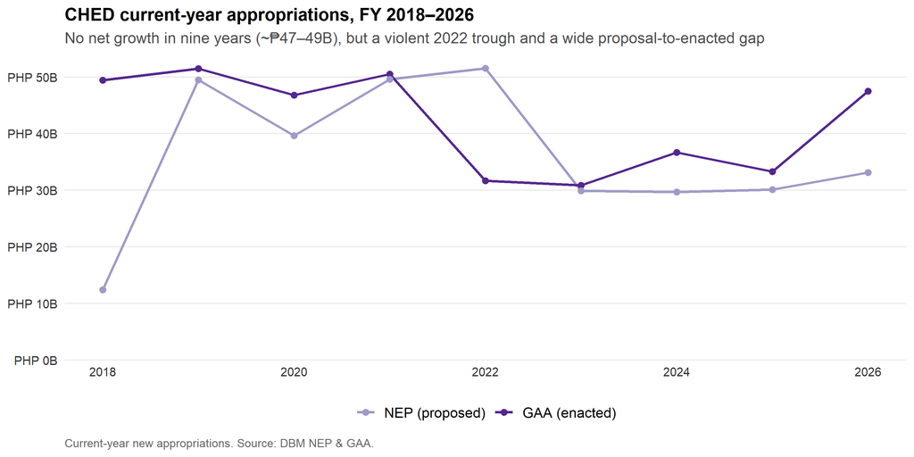

```r
evo <- totals %>% filter(metric %in% c("NEP","GAA")) %>%
  mutate(metric = factor(metric, levels = c("NEP","GAA"), labels = c("NEP (proposed)","GAA (enacted)")))
ggplot(evo, aes(year, total, color = metric, group = metric)) +
  geom_line(linewidth = 1.0) + geom_point(size = 2) +
  scale_color_manual(values = exec_pal) +
  scale_y_continuous(labels = php_b_axis, breaks = pretty_breaks(6), limits = c(0, NA), expand = expansion(mult = c(0, .05))) +
  scale_x_continuous(breaks = seq(2018, 2026, 2)) +
  labs(title = "CHED current-year appropriations, FY 2018–2026",
       subtitle = "No net growth in nine years (~₱47–49B), but a violent 2022 trough and a wide proposal-to-enacted gap",
       x = NULL, y = NULL, caption = "Current-year new appropriations. Source: DBM NEP & GAA.") +
  theme_ched() + guides(color = guide_legend(nrow = 1))
```

```r
totals %>% filter(metric %in% c("NEP","GAA")) %>% mutate(value = total/1e9) %>%
  select(year, metric, value) %>% pivot_wider(names_from = year, values_from = value) %>%
  mutate(metric = factor(metric, levels = c("NEP","GAA"))) %>% arrange(metric) %>% rename(`PHP B` = metric) %>%
  kbl_clean(font = 13, digits = 1, format.args = list(big.mark = ","), na = "")
```

| PHP B | 2018 | 2019 | 2020 | 2021 | 2022 | 2023 | 2024 | 2025 | 2026 |
| --- | --- | --- | --- | --- | --- | --- | --- | --- | --- |
| NEP | 12.4 | 49.5 | 39.7 | 49.6 | 51.5 | 29.9 | 29.7 | 30.1 | 33.1 |
| GAA | 49.4 | 51.5 | 46.8 | 50.5 | 31.7 | 30.9 | 36.7 | 33.3 | 47.5 |

## 3.2 Where Congress adjusts the budget

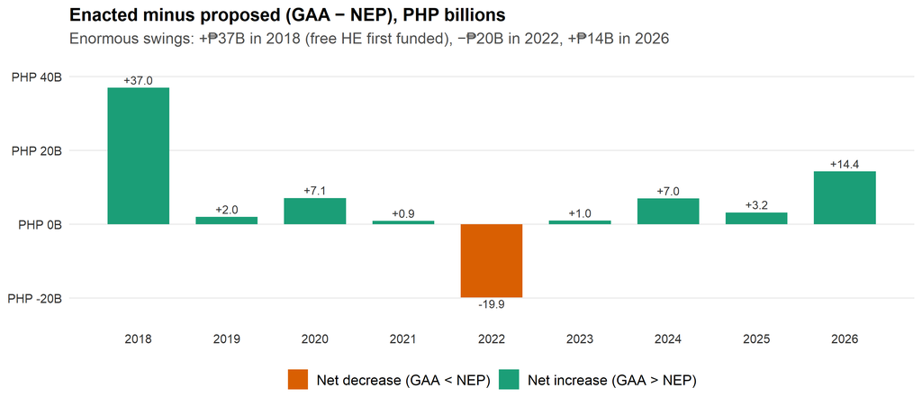

```r
gap <- totals %>% filter(metric %in% c("NEP","GAA")) %>% pivot_wider(names_from = metric, values_from = total) %>%
  mutate(change = GAA - NEP, direction = ifelse(change >= 0, "Net increase (GAA > NEP)", "Net decrease (GAA < NEP)"))
ggplot(gap, aes(year, change/1e9, fill = direction)) +
  geom_col(width = 0.7) +
  geom_text(aes(label = sprintf("%+.1f", change/1e9), vjust = ifelse(change >= 0, -0.4, 1.2)), size = 3.1, color = "grey20") +
  scale_fill_manual(values = c("Net increase (GAA > NEP)" = "#1B9E77", "Net decrease (GAA < NEP)" = "#D95F02")) +
  scale_x_continuous(breaks = 2018:2026) +
  scale_y_continuous(labels = function(v) paste0(peso, v, "B"), expand = expansion(mult = c(0.14, 0.16))) +
  labs(title = "Enacted minus proposed (GAA − NEP), PHP billions",
       subtitle = "Enormous swings: +₱37B in 2018 (free HE first funded), −₱20B in 2022, +₱14B in 2026",
       x = NULL, y = NULL) +
  theme_ched() + guides(fill = guide_legend(nrow = 1))
```

The scale of these adjustments is unusual. The **+₱37B in 2018** reflects the first funding of free higher education — the Executive proposed ₱12B, and Congress raised the enacted budget to ₱49B. The **−₱20B in 2022** was the reverse: a ₱52B proposal cut to ₱32B. For a multi-year entitlement like free tuition, swings of this size are extremely hard to plan around.

## 3.3 Which P/A/Ps does Congress augment?

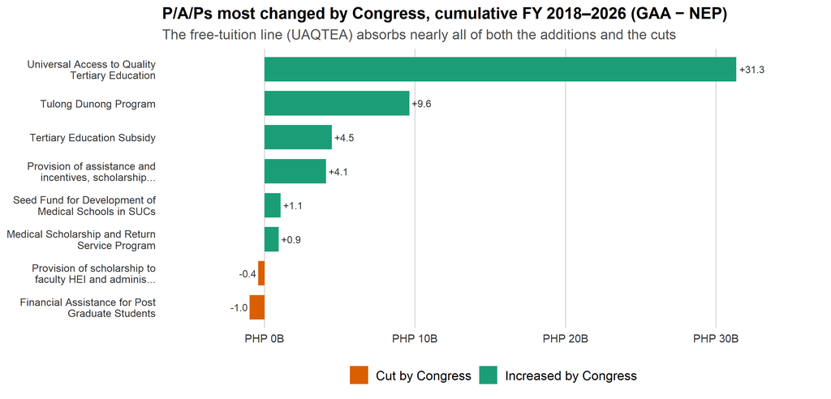

```r
aug <- df_long %>% filter(metric %in% c("NEP","GAA")) %>%
  group_by(pap, year, metric) %>% summarise(amount = sum(amount, na.rm = TRUE), .groups = "drop") %>%
  pivot_wider(names_from = metric, values_from = amount, values_fill = 0) %>%
  mutate(delta = GAA - NEP) %>% group_by(pap) %>% summarise(delta = sum(delta), .groups = "drop")
aug_plot <- bind_rows(aug %>% slice_max(delta, n = 6), aug %>% slice_min(delta, n = 4)) %>%
  filter(abs(delta) > 1e8) %>%
  mutate(dir = ifelse(delta >= 0, "Increased by Congress", "Cut by Congress"),
         pap = factor(pap, levels = pap[order(delta)]))
ggplot(aug_plot, aes(delta/1e9, pap, fill = dir)) +
  geom_col(width = 0.72) +
  geom_text(aes(label = sprintf("%+.1f", delta/1e9), hjust = ifelse(delta >= 0, -0.12, 1.12)), size = 3, color = "grey20") +
  scale_fill_manual(values = c("Increased by Congress" = "#1B9E77", "Cut by Congress" = "#D95F02")) +
  scale_x_continuous(labels = function(v) paste0(peso, v, "B"), expand = expansion(mult = c(0.18, 0.18))) +
  scale_y_discrete(labels = function(x) str_wrap(str_trunc(x, 54), 34)) +
  labs(title = "P/A/Ps most changed by Congress, cumulative FY 2018–2026 (GAA − NEP)",
       subtitle = "The free-tuition line (UAQTEA) absorbs nearly all of both the additions and the cuts",
       x = NULL, y = NULL) +
  theme_ched() + theme(panel.grid.major.y = element_blank(), panel.grid.major.x = element_line(color = "grey85"),
        axis.text.y = element_text(size = 9, lineheight = 0.9)) +
  guides(fill = guide_legend(nrow = 1))
```

# 4 Where the money goes

## 4.1 Composition by PREXC program

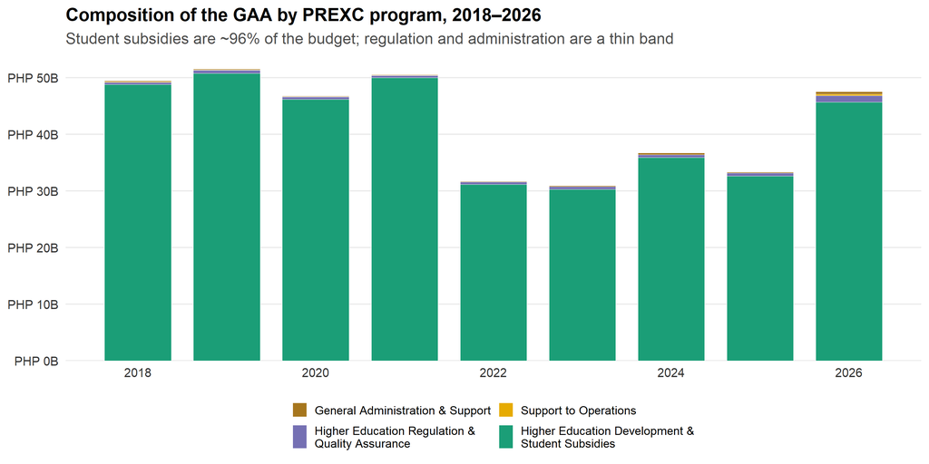

```r
comp <- df_long %>% filter(metric == "GAA", year <= 2026, !is.na(amount), !is.na(category)) %>%
  group_by(year, category) %>% summarise(amount = sum(amount, na.rm = TRUE), .groups = "drop") %>%
  mutate(category = factor(category, levels = names(cat_pal)))
ggplot(comp, aes(year, amount, fill = category)) +
  geom_col(width = 0.75, color = "white", linewidth = 0.2) +
  scale_fill_manual(values = cat_pal, labels = function(x) str_wrap(x, 32)) +
  scale_y_continuous(labels = php_b_axis, breaks = pretty_breaks(6), limits = c(0, NA), expand = expansion(mult = c(0, .05))) +
  scale_x_continuous(breaks = seq(2018, 2026, 2)) +
  labs(title = "Composition of the GAA by PREXC program, 2018–2026",
       subtitle = "Student subsidies are ~96% of the budget; regulation and administration are a thin band",
       x = NULL, y = NULL) +
  theme_ched() + guides(fill = guide_legend(nrow = 2, byrow = TRUE)) +
  theme(legend.text = element_text(size = 9), legend.key.size = unit(0.4, "cm"))
```

The green **Higher Education Development & Student Subsidies** program is essentially the whole budget — about 96% in 2026. What CHED is best known for as an institution — **regulation and quality assurance** (purple) — is a sliver, alongside administration and support. In budget terms, CHED’s regulatory function and its subsidy function are almost entirely different in scale: the agency spends the overwhelming majority of its money moving tuition subsidies to students, not regulating institutions.

## 4.2 Composition by expense class

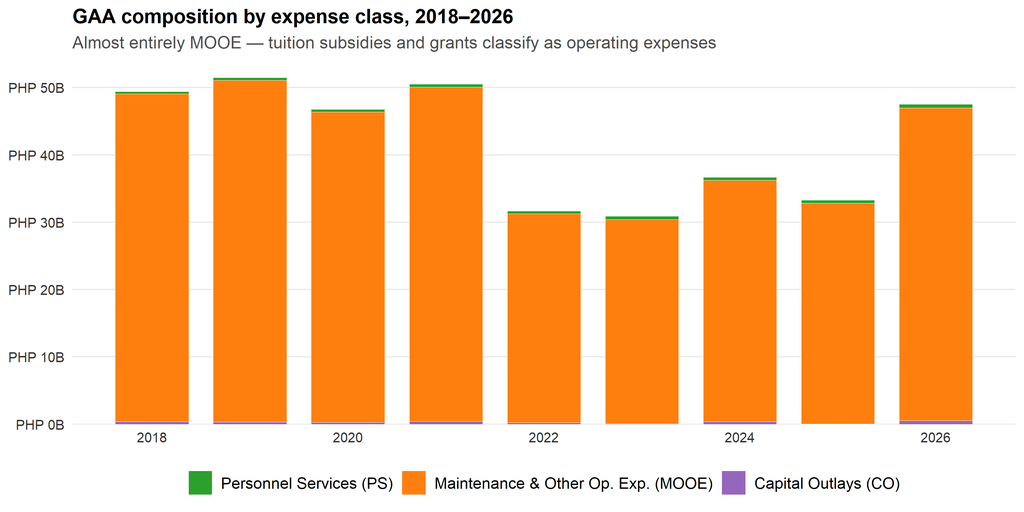

```r
ec_levels <- c("Personnel Services (PS)","Maintenance & Other Op. Exp. (MOOE)","Capital Outlays (CO)")
comp_ec <- df_long_all %>% filter(metric == "GAA", year <= 2026, expense_class %in% c("1PS","2MOOE","6CO")) %>%
  group_by(year, expense_class) %>% summarise(amount = sum(amount, na.rm = TRUE), .groups = "drop") %>%
  mutate(expense_class = factor(expense_class, levels = c("1PS","2MOOE","6CO"), labels = ec_levels))
ggplot(comp_ec, aes(year, amount, fill = expense_class)) +
  geom_col(width = 0.75, color = "white", linewidth = 0.2) +
  scale_fill_manual(values = ec_pal) +
  scale_y_continuous(labels = php_b_axis, breaks = pretty_breaks(6), limits = c(0, NA), expand = expansion(mult = c(0, .05))) +
  scale_x_continuous(breaks = seq(2018, 2026, 2)) +
  labs(title = "GAA composition by expense class, 2018–2026",
       subtitle = "Almost entirely MOOE — tuition subsidies and grants classify as operating expenses",
       x = NULL, y = NULL) +
  theme_ched() + guides(fill = guide_legend(nrow = 1))
```

CHED is an overwhelmingly **MOOE** agency: because tuition subsidies and grants book as operating expenses, maintenance-and-operating spending dominates, with a thin personnel line and little capital. The expense-class mix simply mirrors the program mix — this is a budget for transferring money to and on behalf of students.

## 4.3 The largest P/A/Ps

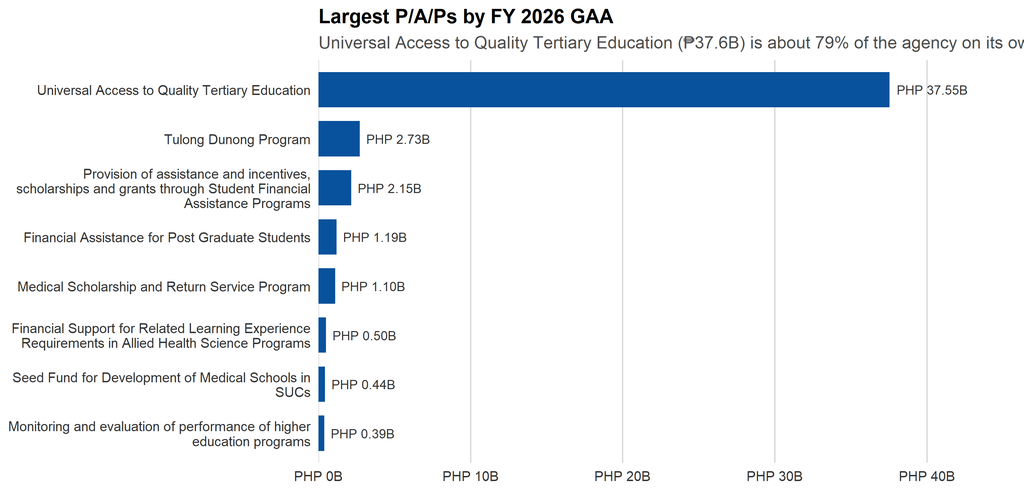

```r
top_paps <- pap_year %>% filter(year == 2026, !is.na(GAA), GAA > 0) %>% arrange(desc(GAA)) %>%
  slice_head(n = 8) %>% mutate(pap = factor(pap, levels = rev(pap)))
ggplot(top_paps, aes(pap, GAA)) +
  geom_col(fill = bar_fill, width = 0.72) +
  geom_text(aes(label = php_b(GAA)), hjust = -0.1, size = 3.2, color = "grey20") +
  coord_flip() + scale_x_discrete(labels = function(x) str_wrap(x, 50)) +
  scale_y_continuous(labels = php_b_axis, expand = expansion(mult = c(0, .22)), limits = c(0, NA)) +
  labs(title = "Largest P/A/Ps by FY 2026 GAA",
       subtitle = "Universal Access to Quality Tertiary Education (₱37.6B) is about 79% of the agency on its own",
       x = NULL, y = NULL) +
  theme_ched() + theme(panel.grid.major.y = element_blank(), panel.grid.major.x = element_line(color = "grey85"))
```

The concentration is extreme: **UAQTEA (₱37.6B)** — free tuition at state universities and colleges — is nearly four-fifths of the entire agency, dwarfing the next lines: the **Tulong Dunong** grant program (₱2.7B), other scholarships and incentives (₱2.2B), post-graduate and medical scholarships (~₱1B each). CHED’s regulatory and monitoring lines do not appear until far down the list.

### Full P/A/P ranking, FY 2026 (interactive)

```r
pap_year %>% filter(year == 2026, !is.na(GAA)) %>%
  left_join(pap_year %>% filter(year == 2025) %>% transmute(pap, GAA25 = GAA), by = "pap") %>%
  transmute(`P/A/P` = pap, `NEP 2026 (B)` = NEP/1e9, `GAA 2026 (B)` = GAA/1e9,
            `GAA 2025 (B)` = GAA25/1e9, `Net add 2026 (B)` = (GAA - NEP)/1e9) %>%
  arrange(desc(`GAA 2026 (B)`)) %>%
  dt_table(page = 10, money_cols = c("NEP 2026 (B)","GAA 2026 (B)","GAA 2025 (B)","Net add 2026 (B)"))
```

| P/A/P | NEP 2026 (B) | GAA 2026 (B) | GAA 2025 (B) | Net add 2026 (B) |
| --- | --- | --- | --- | --- |
| Universal Access to Quality Tertiary Education | 27.406787 | 37.546564 |  | 10.139777 |
| Tulong Dunong Program | 0 | 2.727746 | 2.05725 | 2.727746 |
| Provision of assistance and incentives, scholarships and grants through Student Financial Assistance Programs | 2.154418 | 2.154418 | 1.516929 | 0 |
| Financial Assistance for Post Graduate Students | 1.193 | 1.193 | 0.505 | 0 |
| Medical Scholarship and Return Service Program | 0.909994 | 1.09597 | 0.909994 | 0.185976 |
| Financial Support for Related Learning Experience Requirements in Allied Health Science Programs | 0 | 0.5 |  | 0.5 |
| Seed Fund for Development of Medical Schools in SUCs | 0.15 | 0.44 | 0.15 | 0.29 |
| Monitoring and evaluation of performance of higher education programs | 0.391348 | 0.391348 | 0.413887 | 0 |
| Implementation of the Information System Strategic Plan (ISSP) | 0.232981 | 0.232981 |  | 0 |
| Capacity Building and Research for State Universities and Colleges | 0.160165 | 0.228 |  | 0.067835 |

[output cut: 19 more lines]

# 5 Overall budget utilization

With no program-level execution data, utilization can only be read at the **agency aggregate**, and on a different basis from the appropriations above (all available funds, not just current-year new appropriations). On that basis CHED’s execution is **strikingly weak** — a chronic gap between money released and money spent.

## 5.1 Execution over time

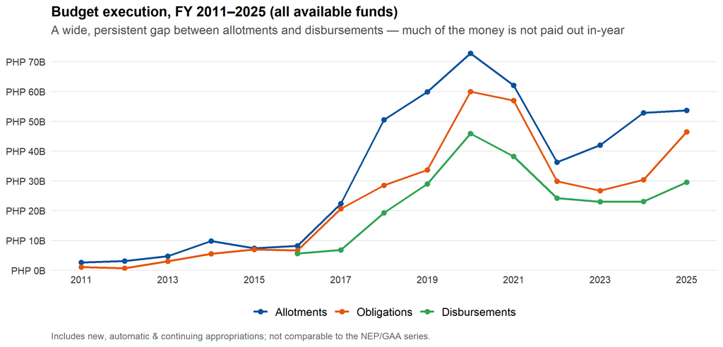

```r
el <- exec %>% select(year, Allotments, Obligations, Disbursements) %>%
  pivot_longer(-year, names_to = "stage", values_to = "amount") %>% filter(!is.na(amount)) %>%
  mutate(stage = factor(stage, levels = c("Allotments","Obligations","Disbursements")))
ggplot(el, aes(year, amount, color = stage, group = stage)) +
  geom_line(linewidth = 1.0) + geom_point(size = 2) +
  scale_color_manual(values = exec_pal) +
  scale_y_continuous(labels = php_b_axis, breaks = pretty_breaks(6), limits = c(0, NA), expand = expansion(mult = c(0, .05))) +
  scale_x_continuous(breaks = seq(2011, 2025, 2)) +
  labs(title = "Budget execution, FY 2011–2025 (all available funds)",
       subtitle = "A wide, persistent gap between allotments and disbursements — much of the money is not paid out in-year",
       x = NULL, y = NULL, caption = "Includes new, automatic & continuing appropriations; not comparable to the NEP/GAA series.") +
  theme_ched() + guides(color = guide_legend(nrow = 1))
```

The gap between the **allotment** line and the **disbursement** line is the story: large sums are released but not spent within the year, and they accumulate as unspent balances that carry forward. For a program meant to pay tuition on students’ behalf each semester, that persistent lag is the central concern.

## 5.2 Absorptive capacity

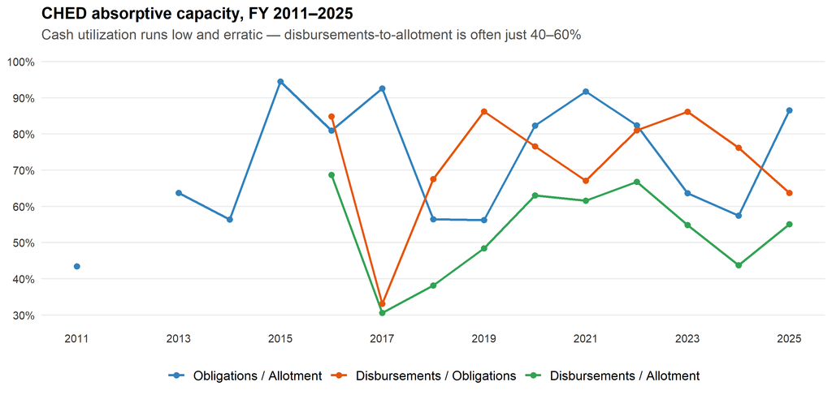

```r
absorp_long <- exec %>% select(year, oblig_allot, disb_oblig, disb_allot) %>%
  pivot_longer(-year, names_to = "ratio", values_to = "value") %>% filter(!is.na(value)) %>%
  mutate(ratio = factor(ratio, levels = c("oblig_allot","disb_oblig","disb_allot"),
    labels = c("Obligations / Allotment","Disbursements / Obligations","Disbursements / Allotment")))
ggplot(absorp_long, aes(year, value, color = ratio, group = ratio)) +
  geom_line(linewidth = 0.9) + geom_point(size = 2) +
  scale_color_manual(values = absorp_pal) +
  scale_y_continuous(labels = percent_format(accuracy = 1), limits = c(0.3, 1.0), breaks = seq(0.3, 1, 0.1)) +
  scale_x_continuous(breaks = seq(2011, 2025, 2)) +
  labs(title = "CHED absorptive capacity, FY 2011–2025",
       subtitle = "Cash utilization runs low and erratic — disbursements-to-allotment is often just 40–60%",
       x = NULL, y = NULL) +
  theme_ched() + guides(color = guide_legend(nrow = 1))
```

### Execution at a glance (interactive)

```r
exec %>% transmute(Year = year, `Allotments (B)` = Allotments/1e9, `Obligations (B)` = Obligations/1e9,
            `Disbursements (B)` = Disbursements/1e9, `O/A` = oblig_allot, `D/O` = disb_oblig, `D/A` = disb_allot) %>%
  dt_table(page = 15, money_cols = c("Allotments (B)","Obligations (B)","Disbursements (B)"),
           pct_cols = c("O/A","D/O","D/A"))
```

| Year | Allotments (B) | Obligations (B) | Disbursements (B) | O/A | D/O | D/A |
| --- | --- | --- | --- | --- | --- | --- |
| 2011 | 2.627193 | 1.140792 |  | 0.4342246648799689 |  |  |
| 2012 | 3.136811 | 0.670043 |  | 0.2136064302248366 |  |  |
| 2013 | 4.73888 | 3.02159 |  | 0.6376169052603147 |  |  |
| 2014 | 9.841594 | 5.552383 |  | 0.564175173249374 |  |  |
| 2015 | 7.443956 | 7.036217 |  | 0.9452254956907322 |  |  |
| 2016 | 8.227287 | 6.662221 | 5.650711 | 0.809771313435401 | 0.848172253667358 | 0.6868255598716807 |
| 2017 | 22.343845 | 20.676754 | 6.842521 | 0.9253892514918538 | 0.3309282008191421 | 0.3062374000535718 |
| 2018 | 50.546776 | 28.542214 | 19.289401 | 0.5646693272781631 | 0.6758200677775031 | 0.3816148630330053 |
| 2019 | 59.897922 | 33.668423 | 29.025786 | 0.5620966784123163 | 0.8621070847304015 | 0.484587528762684 |
| 2020 | 72.839925 | 59.965316 | 45.94223 | 0.8232479097143497 | 0.7661467172123299 | 0.6307286834795616 |

[output cut: 5 more lines]

PHP billions, all-funds basis. O/A = obligations ÷ allotment; D/O = disbursements ÷ obligations; D/A = disbursements ÷ allotment. Not comparable to the NEP/GAA appropriations series above.

# 6 Questions for discussion

1. **A regulator that mostly disburses subsidies.** About 96% of CHED’s budget is student subsidies; quality assurance and regulation — its statutory core — is around 2%. Is the balance between funding higher education and *governing* it the right one?
2. **Why isn’t the money reaching students?** Only ~40–60% of the allotment is disbursed in-year, and unspent free-tuition balances build up. What is causing the lag — eligibility processing, enrolment timing, coordination with SUCs — and how much reaches students late or not at all?
3. **Flat funding, rising demand.** The budget has not grown since 2018 while enrolment and costs have risen. Can a flat appropriation sustain a demand-driven entitlement like free higher education, and what gives if it cannot?
4. **Living with volatility.** A +₱37B / −₱20B swing between years is hard to plan around for a multi-year commitment. How should a tuition-subsidy program be budgeted so that funding is predictable for students and institutions?
5. **What would program-level execution data show?** With no FAR No. 1, we can see that CHED’s overall disbursement lags badly, but not *which* subsidy or scholarship lines are stalling. Program-level records would show exactly where the free-tuition money is getting stuck.

Underlying data: DBM NEP & GAA documents (current-year new appropriations, P/A/P level), FY 2018–2026; DBM-published execution aggregates (all available funds, agency level), FY 2011–2025. CHED has been an Other Executive Office (attached to the Office of the President) throughout the period. No FAR No. 1 (P/A/P-level execution) was available for CHED, so absorption is reported only at the agency aggregate, on a basis not directly comparable to the appropriations series; note that unspent free-tuition balances carry forward as continuing appropriations. Prepared as the long-form companion to the CHED budget briefing.